# Supervised_Learning

```python
# Import Libraries and Load Dataset

import warnings
warnings.filterwarnings('ignore')
```

```python
import pandas as pd

from sklearn.linear_model import LogisticRegression

import pandas_profiling
# importing ploting libraries
import matplotlib.pyplot as plt
# To enable plotting graphs in Jupyter notebook
%matplotlib inline

#importing seaborn for statistical plots
import seaborn as sns

#Let us break the X and y dataframes into training set and test set. For this we will use
#Sklearn package's data splitting function which is based on random function

from sklearn.model_selection import train_test_split

import numpy as np
from scipy import stats

# calculate accuracy measures and confusion matrix
from sklearn import metrics
```

```python
df = pd.read_csv('Bank_Personal_Loan_Modelling.csv')
df.head()
```

|  | ID | Age | Experience | Income | ZIP Code | Family | CCAvg | Education | Mortgage | Personal Loan | Securities Account | CD Account | Online | CreditCard |
| --- | --- | --- | --- | --- | --- | --- | --- | --- | --- | --- | --- | --- | --- | --- |
| 0 | 1 | 25 | 1 | 49 | 91107 | 4 | 1.6 | 1 | 0 | 0 | 1 | 0 | 0 | 0 |
| 1 | 2 | 45 | 19 | 34 | 90089 | 3 | 1.5 | 1 | 0 | 0 | 1 | 0 | 0 | 0 |
| 2 | 3 | 39 | 15 | 11 | 94720 | 1 | 1.0 | 1 | 0 | 0 | 0 | 0 | 0 | 0 |
| 3 | 4 | 35 | 9 | 100 | 94112 | 1 | 2.7 | 2 | 0 | 0 | 0 | 0 | 0 | 0 |
| 4 | 5 | 35 | 8 | 45 | 91330 | 4 | 1.0 | 2 | 0 | 0 | 0 | 0 | 0 | 1 |

```python
df.shape
```

```
(5000, 14)
```

```python
df.info()
```

```
<class 'pandas.core.frame.DataFrame'>
RangeIndex: 5000 entries, 0 to 4999
Data columns (total 14 columns):
 #   Column              Non-Null Count  Dtype
---  ------              --------------  -----
 0   ID                  5000 non-null   int64
 1   Age                 5000 non-null   int64
 2   Experience          5000 non-null   int64
 3   Income              5000 non-null   int64
 4   ZIP Code            5000 non-null   int64
 5   Family              5000 non-null   int64
 6   CCAvg               5000 non-null   float64
 7   Education           5000 non-null   int64
 8   Mortgage            5000 non-null   int64
 9   Personal Loan       5000 non-null   int64
 10  Securities Account  5000 non-null   int64
 11  CD Account          5000 non-null   int64
 12  Online              5000 non-null   int64
 13  CreditCard          5000 non-null   int64
dtypes: float64(1), int64(13)
memory usage: 547.0 KB
```

```python
#Lets analysze the distribution of the various attribute
df.describe().transpose()
```

|  | count | mean | std | min | 25% | 50% | 75% | max |
| --- | --- | --- | --- | --- | --- | --- | --- | --- |
| ID | 5000.0 | 2500.500000 | 1443.520003 | 1.0 | 1250.75 | 2500.5 | 3750.25 | 5000.0 |
| Age | 5000.0 | 45.338400 | 11.463166 | 23.0 | 35.00 | 45.0 | 55.00 | 67.0 |
| Experience | 5000.0 | 20.104600 | 11.467954 | -3.0 | 10.00 | 20.0 | 30.00 | 43.0 |
| Income | 5000.0 | 73.774200 | 46.033729 | 8.0 | 39.00 | 64.0 | 98.00 | 224.0 |
| ZIP Code | 5000.0 | 93152.503000 | 2121.852197 | 9307.0 | 91911.00 | 93437.0 | 94608.00 | 96651.0 |
| Family | 5000.0 | 2.396400 | 1.147663 | 1.0 | 1.00 | 2.0 | 3.00 | 4.0 |
| CCAvg | 5000.0 | 1.937938 | 1.747659 | 0.0 | 0.70 | 1.5 | 2.50 | 10.0 |
| Education | 5000.0 | 1.881000 | 0.839869 | 1.0 | 1.00 | 2.0 | 3.00 | 3.0 |
| Mortgage | 5000.0 | 56.498800 | 101.713802 | 0.0 | 0.00 | 0.0 | 101.00 | 635.0 |
| Personal Loan | 5000.0 | 0.096000 | 0.294621 | 0.0 | 0.00 | 0.0 | 0.00 | 1.0 |
| Securities Account | 5000.0 | 0.104400 | 0.305809 | 0.0 | 0.00 | 0.0 | 0.00 | 1.0 |
| CD Account | 5000.0 | 0.060400 | 0.238250 | 0.0 | 0.00 | 0.0 | 0.00 | 1.0 |
| Online | 5000.0 | 0.596800 | 0.490589 | 0.0 | 0.00 | 1.0 | 1.00 | 1.0 |
| CreditCard | 5000.0 | 0.294000 | 0.455637 | 0.0 | 0.00 | 0.0 | 1.00 | 1.0 |

```python
df.isnull().sum() # No null values.
```

```
ID                    0
Age                   0
Experience            0
Income                0
ZIP Code              0
Family                0
CCAvg                 0
Education             0
Mortgage              0
Personal Loan         0
Securities Account    0
CD Account            0
Online                0
CreditCard            0
dtype: int64
```

```python
df.nunique() # Number of unique values in a column
```

```
ID                    5000
Age                     45
Experience              47
Income                 162
ZIP Code               467
Family                   4
CCAvg                  108
Education                3
Mortgage               347
Personal Loan            2
Securities Account       2
CD Account               2
Online                   2
CreditCard               2
dtype: int64
```

```python
ln_df = df.drop('ID', axis =1 ) # dropping this column as it will be 1-1 mapping anyways
ln_df.head()
```

|  | Age | Experience | Income | ZIP Code | Family | CCAvg | Education | Mortgage | Personal Loan | Securities Account | CD Account | Online | CreditCard |
| --- | --- | --- | --- | --- | --- | --- | --- | --- | --- | --- | --- | --- | --- |
| 0 | 25 | 1 | 49 | 91107 | 4 | 1.6 | 1 | 0 | 0 | 1 | 0 | 0 | 0 |
| 1 | 45 | 19 | 34 | 90089 | 3 | 1.5 | 1 | 0 | 0 | 1 | 0 | 0 | 0 |
| 2 | 39 | 15 | 11 | 94720 | 1 | 1.0 | 1 | 0 | 0 | 0 | 0 | 0 | 0 |
| 3 | 35 | 9 | 100 | 94112 | 1 | 2.7 | 2 | 0 | 0 | 0 | 0 | 0 | 0 |
| 4 | 35 | 8 | 45 | 91330 | 4 | 1.0 | 2 | 0 | 0 | 0 | 0 | 0 | 1 |

```python
len(ln_df[ln_df['Mortgage']==0]) #Number of people with zero mortgage
```

```
3462
```

```python
len(ln_df[ln_df['CreditCard']==0]) #Number of people with zero credit card spending per month
```

```
3530
```

```python
# Value counts of all categorical columns - Family
ln_df['Family'].value_counts(normalize=True)
```

```
1    0.2944
2    0.2592
4    0.2444
3    0.2020
Name: Family, dtype: float64
```

```python
# Value counts of all categorical columns - Education

ln_df['Education'].value_counts(normalize=True)
```

```
1    0.4192
3    0.3002
2    0.2806
Name: Education, dtype: float64
```

```python
ln_df.profile_report() #Univariate study using pandas_profiling for detailed data analysis
```

[interactive chart not shown]

```python
# Fact Check - Is Age vs Experience highly correlated ?

ln_df['Experience'].corr(ln_df['Age'])
```

```
0.9942148569683319
```

```python
# Experience is highly correlated with Age and it is not required to proceed further
ln_df = ln_df.drop('Experience', axis =1 )
ln_df.head()
```

|  | Age | Income | ZIP Code | Family | CCAvg | Education | Mortgage | Personal Loan | Securities Account | CD Account | Online | CreditCard |
| --- | --- | --- | --- | --- | --- | --- | --- | --- | --- | --- | --- | --- |
| 0 | 25 | 49 | 91107 | 4 | 1.6 | 1 | 0 | 0 | 1 | 0 | 0 | 0 |
| 1 | 45 | 34 | 90089 | 3 | 1.5 | 1 | 0 | 0 | 1 | 0 | 0 | 0 |
| 2 | 39 | 11 | 94720 | 1 | 1.0 | 1 | 0 | 0 | 0 | 0 | 0 | 0 |
| 3 | 35 | 100 | 94112 | 1 | 2.7 | 2 | 0 | 0 | 0 | 0 | 0 | 0 |
| 4 | 35 | 45 | 91330 | 4 | 1.0 | 2 | 0 | 0 | 0 | 0 | 0 | 1 |

```python
# Also Zipcode is just numbers and it is not required for further analysis
ln_df = ln_df.drop('ZIP Code', axis =1 )
ln_df.head()
```

|  | Age | Income | Family | CCAvg | Education | Mortgage | Personal Loan | Securities Account | CD Account | Online | CreditCard |
| --- | --- | --- | --- | --- | --- | --- | --- | --- | --- | --- | --- |
| 0 | 25 | 49 | 4 | 1.6 | 1 | 0 | 0 | 1 | 0 | 0 | 0 |
| 1 | 45 | 34 | 3 | 1.5 | 1 | 0 | 0 | 1 | 0 | 0 | 0 |
| 2 | 39 | 11 | 1 | 1.0 | 1 | 0 | 0 | 0 | 0 | 0 | 0 |
| 3 | 35 | 100 | 1 | 2.7 | 2 | 0 | 0 | 0 | 0 | 0 | 0 |
| 4 | 35 | 45 | 4 | 1.0 | 2 | 0 | 0 | 0 | 0 | 0 | 1 |

```python
# Bivariate Analysis

# Let us look at the target column which is 'Personal Loan' to understand how the data is distributed amongst the various values
ln_df.groupby(["Personal Loan"]).mean()
```

| Personal Loan | Age | Income | Family | CCAvg | Education | Mortgage | Securities Account | CD Account | Online | CreditCard |
| --- | --- | --- | --- | --- | --- | --- | --- | --- | --- | --- |
| 0 | 45.367257 | 66.237389 | 2.373451 | 1.729009 | 1.843584 | 51.789381 | 0.102212 | 0.035841 | 0.595796 | 0.293584 |
| 1 | 45.066667 | 144.745833 | 2.612500 | 3.905354 | 2.233333 | 100.845833 | 0.125000 | 0.291667 | 0.606250 | 0.297917 |

```python
# Let us look at the target column which is 'Personal Loan' to understand how the data is distributed amongst the various values
ln_df.groupby(["Personal Loan"]).median()
```

| Personal Loan | Age | Income | Family | CCAvg | Education | Mortgage | Securities Account | CD Account | Online | CreditCard |
| --- | --- | --- | --- | --- | --- | --- | --- | --- | --- | --- |
| 0 | 45.0 | 59.0 | 2.0 | 1.4 | 2.0 | 0.0 | 0.0 | 0.0 | 1.0 | 0.0 |
| 1 | 45.0 | 142.5 | 3.0 | 3.8 | 2.0 | 0.0 | 0.0 | 0.0 | 1.0 | 0.0 |

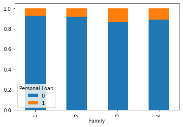

```python
# Lets understand further more based on univariate study against target variable which is personal loan here.

# Start with Categorical variables (Family and Education)

# Family vs Personal Loan Factor

familyvspersonalloanfactor = pd.crosstab(ln_df['Family'], ln_df['Personal Loan'])
familyvspersonalloanfactor.div(familyvspersonalloanfactor.sum(1).astype(float), axis=0).plot(kind='bar', stacked=True)
```

```python
print('familyvspersonalloanfactor: \n', familyvspersonalloanfactor)
```

```
familyvspersonalloanfactor:
 Personal Loan     0    1
Family
1              1365  107
2              1190  106
3               877  133
4              1088  134
```

```python
# Not able to derive with the family size, hence check education categorical variable.
print('familyvspersonalloanfactor in % : \n', familyvspersonalloanfactor.div(familyvspersonalloanfactor.sum(1).astype(float), axis=0))
```

```
familyvspersonalloanfactor in % :
 Personal Loan         0         1
Family
1              0.927310  0.072690
2              0.918210  0.081790
3              0.868317  0.131683
4              0.890344  0.109656
```

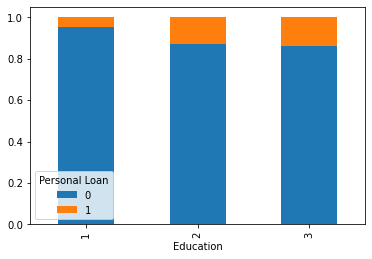

```python
# Education vs Personal Loan Factor

educationvspersonalloanfactor = pd.crosstab(ln_df['Education'], ln_df['Personal Loan'])
educationvspersonalloanfactor.div(educationvspersonalloanfactor.sum(1).astype(float), axis=0).plot(kind='bar', stacked=True)
```

```python
print('educationvspersonalloanfactor: \n', educationvspersonalloanfactor)
```

```
educationvspersonalloanfactor:
 Personal Loan     0    1
Education
1              2003   93
2              1221  182
3              1296  205
```

```python
# Customers who are more educated chances of getting personal loan
print('educationvspersonalloanfactor in % : \n', educationvspersonalloanfactor.div(educationvspersonalloanfactor.sum(1).astype(float), axis=0))
```

```
educationvspersonalloanfactor in % :
 Personal Loan         0         1
Education
1              0.955630  0.044370
2              0.870278  0.129722
3              0.863424  0.136576
```

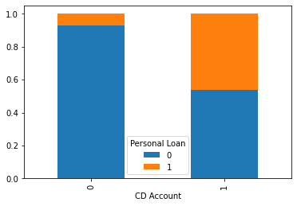

```python
# Start with Boolean variables (CD Account, CreditCard, Online, Securities Account)

# CD Account vs Personal Loan Factor

cdaccountvspersonalloanfactor = pd.crosstab(ln_df['CD Account'], ln_df['Personal Loan'])
cdaccountvspersonalloanfactor.div(cdaccountvspersonalloanfactor.sum(1).astype(float), axis=0).plot(kind='bar', stacked=True)
```

```python
print('cdaccountvspersonalloanfactor: \n', cdaccountvspersonalloanfactor)
```

```
cdaccountvspersonalloanfactor:
 Personal Loan     0    1
CD Account
0              4358  340
1               162  140
```

```python
#Customers who has a CD deposit chances of getting personal loan
print('cdaccountvspersonalloanfactor in % : \n', cdaccountvspersonalloanfactor.div(cdaccountvspersonalloanfactor.sum(1).astype(float), axis=0))
```

```
cdaccountvspersonalloanfactor in % :
 Personal Loan         0         1
CD Account
0              0.927629  0.072371
1              0.536424  0.463576
```

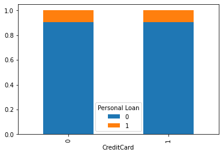

```python
# Credit Card vs Personal Loan Factor

creditcardaccountvspersonalloanfactor = pd.crosstab(ln_df['CreditCard'], ln_df['Personal Loan'])
creditcardaccountvspersonalloanfactor.div(creditcardaccountvspersonalloanfactor.sum(1).astype(float), axis=0).plot(kind='bar', stacked=True)
```

```python
print('creditcardaccountvspersonalloanfactor: \n', creditcardaccountvspersonalloanfactor)
```

```
creditcardaccountvspersonalloanfactor:
 Personal Loan     0    1
CreditCard
0              3193  337
1              1327  143
```

```python
# Customers with credit card/ no credit card values seems to be inline, it doesnt derive any conclusion. lets check with another boolean variable
print('creditcardaccountvspersonalloanfactor in % : \n', creditcardaccountvspersonalloanfactor.div(creditcardaccountvspersonalloanfactor.sum(1).astype(float), axis=0))
```

```
creditcardaccountvspersonalloanfactor in % :
 Personal Loan         0         1
CreditCard
0              0.904533  0.095467
1              0.902721  0.097279
```

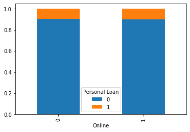

```python
# Online vs Personal Loan Factor
onlinevspersonalloanfactor = pd.crosstab(ln_df['Online'], ln_df['Personal Loan'])
onlinevspersonalloanfactor.div(onlinevspersonalloanfactor.sum(1).astype(float), axis=0).plot(kind='bar', stacked=True)
```

```python
print('onlinevspersonalloanfactor: \n', onlinevspersonalloanfactor)
```

```
onlinevspersonalloanfactor:
 Personal Loan     0    1
Online
0              1827  189
1              2693  291
```

```python
# Customers with online banking/ no online banking values seems to be inline, it doesnt derive any conclusion. lets check with another boolean variable
print('onlinevspersonalloanfactor in % : \n', onlinevspersonalloanfactor.div(onlinevspersonalloanfactor.sum(1).astype(float), axis=0))
```

```
onlinevspersonalloanfactor in % :
 Personal Loan        0        1
Online
0              0.90625  0.09375
1              0.90248  0.09752
```

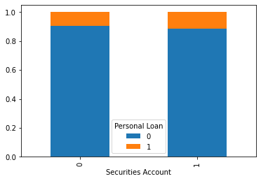

```python
# Securities Account vs Personal Loan Factor

securitiesaccountvspersonalloanfactor = pd.crosstab(ln_df['Securities Account'], ln_df['Personal Loan'])
securitiesaccountvspersonalloanfactor.div(securitiesaccountvspersonalloanfactor.sum(1).astype(float), axis=0).plot(kind='bar', stacked=True)
```

```python
print('securitiesaccountvspersonalloanfactor: \n', securitiesaccountvspersonalloanfactor)
```

```
securitiesaccountvspersonalloanfactor:
 Personal Loan          0    1
Securities Account
0                   4058  420
1                    462   60
```

```python
# Customers with securities account/ no securities account values seems to be inline, it doesnt derive any conclusion. lets check with another boolean variable
print('securitiesaccountvspersonalloanfactor in % : \n', securitiesaccountvspersonalloanfactor.div(securitiesaccountvspersonalloanfactor.sum(1).astype(float), axis=0))
```

```
securitiesaccountvspersonalloanfactor in % :
 Personal Loan              0         1
Securities Account
0                   0.906208  0.093792
1                   0.885057  0.114943
```

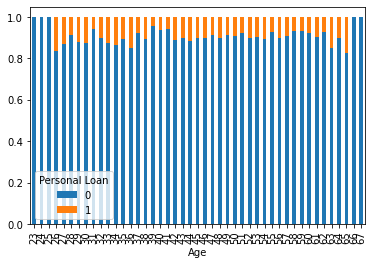

```python
# Start with independent variables (Age, CCAvg, Income, Mortgage, Experience)

# Age vs Personal Loan Factor

agevspersonalloanfactor = pd.crosstab(ln_df['Age'], ln_df['Personal Loan'])
agevspersonalloanfactor.div(agevspersonalloanfactor.sum(1).astype(float), axis=0).plot(kind='bar', stacked=True)
```

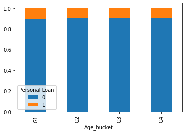

```python
# its difficult to view lets bucket age group and derive conclusion
bucket = [27,35,45,55,75]
groups = ['G1','G2', 'G3', 'G4']
ln_df['Age_bucket'] = pd.cut(ln_df['Age'], bucket, labels=groups)
agebucketvspersonalloanfactor = pd.crosstab(ln_df['Age_bucket'], ln_df['Personal Loan'])
agebucketvspersonalloanfactor.div(agebucketvspersonalloanfactor.sum(1).astype(float), axis=0).plot(kind='bar', stacked=True)
```

```python
print('agebucketvspersonalloanfactor: \n', agebucketvspersonalloanfactor)
```

```
agebucketvspersonalloanfactor:
 Personal Loan     0    1
Age_bucket
G1              903  109
G2             1131  114
G3             1147  118
G4             1102  114
```

```python
# Customers with all age group values seems to be inline, it doesnt derive any conclusion. lets check with another boolean variable
print('agebucketvspersonalloanfactor in % : \n', agebucketvspersonalloanfactor.div(agebucketvspersonalloanfactor.sum(1).astype(float), axis=0))
```

```
agebucketvspersonalloanfactor in % :
 Personal Loan         0         1
Age_bucket
G1             0.892292  0.107708
G2             0.908434  0.091566
G3             0.906719  0.093281
G4             0.906250  0.093750
```

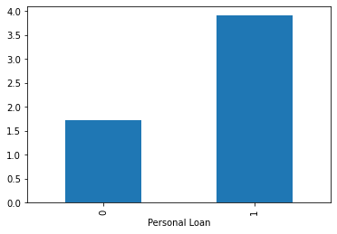

```python
# CCAvg vs Personal Loan Factor, Lets take mean to find out quick on  CCAvg vs Personal Loan
# Customers who spend credit card are more likely to avail personal loan
ln_df.groupby('Personal Loan')['CCAvg'].mean().plot(kind='bar')
```

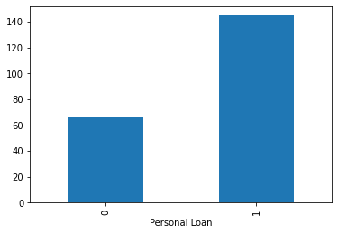

```python
# Income vs Personal Loan Factor, Lets take mean to find out quick on  Income vs Personal Loan
# Customers who has more income are more likely to avail personal loan

ln_df.groupby('Personal Loan')['Income'].mean().plot(kind='bar')
```

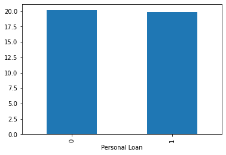

```python
# Experience vs Personal Loan Factor, Lets take mean to find out quick on  Experience vs Personal Loan
# Experience is highly correlated this is expected plotting experience column from original data set.

df.groupby('Personal Loan')['Experience'].mean().plot(kind='bar')
```

```python
## Define X and Y variables

X = ln_df.drop('Personal Loan', axis=1)
Y = ln_df['Personal Loan']
```

```python
#Convert categorical vriables to dummy variables
X = pd.get_dummies(X, drop_first=True)
```

```python
##Split into training and test set
from sklearn.model_selection import train_test_split

X_train, X_test, y_train, y_test = train_test_split(X, Y, test_size=0.30,random_state=1)
```

```python
from sklearn.metrics import confusion_matrix, recall_score, precision_score, f1_score, roc_auc_score,accuracy_score
from sklearn.linear_model import LogisticRegression

logreg = LogisticRegression(random_state=1,fit_intercept=False)
logreg.fit(X_train, y_train)                    # fit the model on train data
```

```
LogisticRegression(fit_intercept=False, random_state=1)
```

```python
y_predict = logreg.predict(X_test)              # Predicting the target variable on test data
```

```python
# Observe the predicted and observed classes in a dataframe.

z = X_test.copy()
z['Observed Personal Loan'] = y_test
z['Predicted Personal Loan'] = y_predict
z.tail(10)
```

|  | Age | Income | Family | CCAvg | Education | Mortgage | Securities Account | CD Account | Online | CreditCard | Age_bucket_G2 | Age_bucket_G3 | Age_bucket_G4 | Observed Personal Loan | Predicted Personal Loan |
| --- | --- | --- | --- | --- | --- | --- | --- | --- | --- | --- | --- | --- | --- | --- | --- |
| 797 | 42 | 61 | 3 | 0.50 | 3 | 0 | 0 | 0 | 1 | 0 | 1 | 0 | 0 | 0 | 0 |
| 4495 | 38 | 82 | 4 | 2.67 | 1 | 0 | 0 | 0 | 0 | 0 | 1 | 0 | 0 | 0 | 0 |
| 4972 | 58 | 41 | 3 | 2.20 | 3 | 148 | 0 | 0 | 1 | 1 | 0 | 0 | 1 | 0 | 0 |
| 2925 | 59 | 42 | 4 | 0.40 | 1 | 0 | 0 | 0 | 1 | 0 | 0 | 0 | 1 | 0 | 0 |
| 3836 | 45 | 31 | 3 | 0.50 | 2 | 0 | 0 | 0 | 1 | 1 | 1 | 0 | 0 | 0 | 0 |
| 4140 | 63 | 32 | 1 | 1.50 | 2 | 0 | 0 | 0 | 0 | 0 | 0 | 0 | 1 | 0 | 0 |
| 3969 | 38 | 75 | 3 | 2.33 | 2 | 0 | 0 | 0 | 1 | 0 | 1 | 0 | 0 | 0 | 0 |
| 2535 | 50 | 21 | 2 | 0.70 | 3 | 129 | 0 | 0 | 0 | 0 | 0 | 1 | 0 | 0 | 0 |
| 1361 | 50 | 38 | 4 | 0.90 | 2 | 0 | 0 | 0 | 1 | 0 | 0 | 1 | 0 | 0 | 0 |
| 1458 | 51 | 33 | 1 | 1.40 | 3 | 0 | 0 | 0 | 1 | 1 | 0 | 1 | 0 | 0 | 0 |

```python
## function to get confusion matrix in a proper format
def draw_cm( actual, predicted ):
    cm = confusion_matrix( actual, predicted)
    sns.heatmap(cm, annot=True,  fmt='.2f', xticklabels = [0,1] , yticklabels = [0,1] )
    plt.ylabel('Observed')
    plt.xlabel('Predicted')
    plt.show()
```

```
Training accuracy 0.9331428571428572

Testing accuracy 0.9286666666666666

Confusion Matrix
```

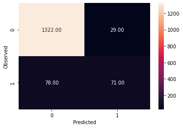

```
None

Recall: 0.47651006711409394

Precision: 0.71

F1 Score: 0.5702811244979918

Roc Auc Score: 0.7275222430315104
```

```python
print("Training accuracy",logreg.score(X_train,y_train))
print()
print("Testing accuracy",logreg.score(X_test, y_test))
print()
print('Confusion Matrix')
print(draw_cm(y_test,y_predict))
print()
print("Recall:",recall_score(y_test,y_predict))
print()
print("Precision:",precision_score(y_test,y_predict))
print()
print("F1 Score:",f1_score(y_test,y_predict))
print()
print("Roc Auc Score:",roc_auc_score(y_test,y_predict))
```

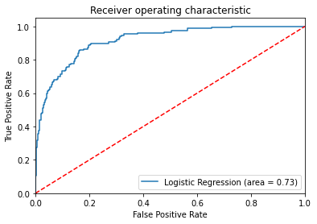

```python
#AUC ROC curve
from sklearn.metrics import roc_auc_score
from sklearn.metrics import roc_curve

logit_roc_auc = roc_auc_score(y_test, logreg.predict(X_test))
fpr, tpr, thresholds = roc_curve(y_test, logreg.predict_proba(X_test)[:,1])
plt.figure()
plt.plot(fpr, tpr, label='Logistic Regression (area = %0.2f)' % logit_roc_auc)
plt.plot([0, 1], [0, 1],'r--')
plt.xlim([0.0, 1.0])
plt.ylim([0.0, 1.05])
plt.xlabel('False Positive Rate')
plt.ylabel('True Positive Rate')
plt.title('Receiver operating characteristic')
plt.legend(loc="lower right")
plt.savefig('Log_ROC')
plt.show()
```

```python
## Feature Importance or Coefficients
fi = pd.DataFrame()
fi['Column'] = X_train.columns
fi['Coefficient'] = np.round(abs(logreg.coef_[0]),2)
fi.sort_values(by='Coefficient',ascending=False)
```

|  | Column | Coefficient |
| --- | --- | --- |
| 7 | CD Account | 4.48 |
| 12 | Age_bucket_G4 | 4.24 |
| 11 | Age_bucket_G3 | 2.07 |
| 9 | CreditCard | 1.53 |
| 6 | Securities Account | 0.97 |
| 10 | Age_bucket_G2 | 0.75 |
| 4 | Education | 0.72 |
| 8 | Online | 0.68 |
| 0 | Age | 0.19 |
| 2 | Family | 0.11 |
| 3 | CCAvg | 0.11 |
| 1 | Income | 0.03 |
| 5 | Mortgage | 0.00 |

```python
# Show all the rows where the predicted class is not equal to the observed class
rslt_df = z[z['Observed Personal Loan'] != z['Predicted Personal Loan']]
rslt_df
```

[output not shown]

## Business Insights

#### `Confusion matrix means`

*True Positive (observed=1,predicted=1):* Predicted that personal loan will be granted and the customer was eligibile for loan

*False Positive (observed=0,predicted=1):* Predicted that personal loan will be granted and the customer was not eligibile for loan

*True Negative (observed=0,predicted=0):* Predicted that personal loan will not be granted and the customer was not eligibile for loan

*False Negative (observed=1,predicted=0):* Predicted that personal loan will not be granted and the customer was eligibile for loan

#### `Important Features:`

"CD Account", "Age_bucket_G4", "CreditCard", "Age_bucket_G3", "Securities Account" seems to be top 5 features which influence the model's output. Based on the coefficients value. "Mortgage" have coefficients value as 0 so these feature doesn't help model in predicting target variable.

#### `Important Metric:`

Thera bank wants to give loan to the people who are eligible for the personal loan i.e. less number of False Positive, if FP is high bank would lose money. So that the bank doesn't lose money on the people who are not eligible for the loan. Hence Precision is the important metric. In case of False negative bank will lose few customers but that okay because the bank would want to retain money more than customers who are not eligible for loan. After achieving the desired accuracy we can deploy the model for practical use. As in the bank now can predict who is eligible for personal loan. They can use the model for upcoming customers.